# Nonlinear Optimization Ex.1

Ariel Vishne 204149371

22 3 2022

## Ex. 1

As seen in class (week #2), we require solving the equation:
$$x - 2sin(x) = 0$$
We saw that the segment $[\frac{\pi}{2}, 2]$ has some positive root. We will find it with bisection and Newton methods.

### Ex. 1-i BISECTION

```r
f <- function(x){
  return(x - 2*sin(x))
}
precision <- 10^-6


a <- (pi / 2)
b <- 2
i <- 0
x <- ((a+b)/2)

while(abs(a-b) > precision){
  i <- i+1
  print(paste("iteration number", i, "current segment [", a,",", b, "]", "Current precision", round(abs(a-b),7)))
  if(f(x)*f(a)<0){
    b <- x
  }
  else if(f(x)*f(b) <0){
    a <- x
  }
  x <- ((a+b)/2)
}
```

```
## [1] "iteration number 1 current segment [ 1.5707963267949 , 2 ] Current precision 0.4292037"
## [1] "iteration number 2 current segment [ 1.78539816339745 , 2 ] Current precision 0.2146018"
## [1] "iteration number 3 current segment [ 1.89269908169872 , 2 ] Current precision 0.1073009"
## [1] "iteration number 4 current segment [ 1.89269908169872 , 1.94634954084936 ] Current precision 0.0536505"
## [1] "iteration number 5 current segment [ 1.89269908169872 , 1.91952431127404 ] Current precision 0.0268252"
## [1] "iteration number 6 current segment [ 1.89269908169872 , 1.90611169648638 ] Current precision 0.0134126"
## [1] "iteration number 7 current segment [ 1.89269908169872 , 1.89940538909255 ] Current precision 0.0067063"
## [1] "iteration number 8 current segment [ 1.89269908169872 , 1.89605223539564 ] Current precision 0.0033532"
## [1] "iteration number 9 current segment [ 1.89437565854718 , 1.89605223539564 ] Current precision 0.0016766"
## [1] "iteration number 10 current segment [ 1.89521394697141 , 1.89605223539564 ] Current precision 0.0008383"
## [1] "iteration number 11 current segment [ 1.89521394697141 , 1.89563309118352 ] Current precision 0.0004191"
## [1] "iteration number 12 current segment [ 1.89542351907747 , 1.89563309118352 ] Current precision 0.0002096"
## [1] "iteration number 13 current segment [ 1.89542351907747 , 1.8955283051305 ] Current precision 0.0001048"
## [1] "iteration number 14 current segment [ 1.89547591210398 , 1.8955283051305 ] Current precision 5.24e-05"
## [1] "iteration number 15 current segment [ 1.89547591210398 , 1.89550210861724 ] Current precision 2.62e-05"
## [1] "iteration number 16 current segment [ 1.89548901036061 , 1.89550210861724 ] Current precision 1.31e-05"
## [1] "iteration number 17 current segment [ 1.89548901036061 , 1.89549555948892 ] Current precision 6.5e-06"
## [1] "iteration number 18 current segment [ 1.89549228492477 , 1.89549555948892 ] Current precision 3.3e-06"
## [1] "iteration number 19 current segment [ 1.89549392220685 , 1.89549555948892 ] Current precision 1.6e-06"
```

### Ex. 1-ii NEWTON

```r
x <- 2
i <- 0

while(f(x) > precision){
  i <- i+1
  print(paste("iteration number", i, "precision reached:", round(abs(f(x)),7), "value reached:", round(x,7)))


  x <- x - ((x-2*sin(x))/(1-2*cos(x)))
}
```

```
## [1] "iteration number 1 precision reached: 0.1814051 value reached: 2"
## [1] "iteration number 2 precision reached: 0.0090401 value reached: 1.9009956"
## [1] "iteration number 3 precision reached: 2.85e-05 value reached: 1.8955116"
```

### Ex. 1-iii Comparison

We can see that the Newton method converges sqared, while bisection converges linear.

## Ex. 2

The desired quantity $\frac{1}{\sqrt2}$ is a solution (a root) to the equation
$$(\sqrt2x - 1)^2 = 0$$
This equation has no division. We therefore will use the Newton method beginning at ${X_0 = 1/2}$.

If we take the derivativ we have:

$$((\sqrt2x - 1)^2)'=2\sqrt2(\sqrt2x-1)=4x-2\sqrt2$$
If we solve the recursive equation and we multiply by $2\sqrt2$ we reach:
$$X_{n+1} = X_{n} - \frac{2\sqrt2f(x)}{f'(x)}=X_n-
\frac{2\sqrt2((\sqrt2x-1)^2)}{2\sqrt2(\sqrt2x-1)}=X_{n}-[\sqrt2x-1]=X_{n}-\sqrt2x+1$$
Thus we have reached an equation for which $\frac{1}{\sqrt2}$ is a root, and which has no division. Beginning at $x_0=0.5$ we get:

```r
f <- function(x){
  return((sqrt(2)*x - 1)^2)
}
precision <- 10^-6
x <- 1/2
i <- 0

while(abs(f(x)) > precision){
  i <- i+1
  print(paste("iteration number", i, "precision reached:", round(abs(f(x)),7), "value reached:", round(x,7)))


  x <- (x - (sqrt(2)*x) + 1)
}
```

```
## [1] "iteration number 1 precision reached: 0.0857864 value reached: 0.5"
## [1] "iteration number 2 precision reached: 0.0147186 value reached: 0.7928932"
## [1] "iteration number 3 precision reached: 0.0025253 value reached: 0.6715729"
## [1] "iteration number 4 precision reached: 0.0004333 value reached: 0.7218254"
## [1] "iteration number 5 precision reached: 7.43e-05 value reached: 0.7010101"
## [1] "iteration number 6 precision reached: 1.28e-05 value reached: 0.7096321"
## [1] "iteration number 7 precision reached: 2.2e-06 value reached: 0.7060608"
```

## Ex. 3

We have
$$f(x) = e^x - x - 1$$
if we look at the derivative we have
$$f'(x) = (e^x - x - 1)' = e^x - 1$$

Since $e^x-1$ has only one root where $e^{x} - 1 =0\Rightarrow e^{x}=1\Rightarrow x = 0$ we only have one maxima/minima point. Since $f''(x) = e^{x} > 0$ for all $x$ then it is a minimum point. We conclude that $x = 0$ is the only root.

### Ex. 3-i Newton

To compare the methods we will begin at $X_0 = 0.125$ and assume precision required of $10^{-4}$ For the regular Newton method we calculate:
$$X_{n+1} = X_{n} - \frac{f(X_n)}{f'(X_n)} = X_n -\frac{e^{X_n} -
X_n - 1}{e^{X_n}} = X_n - 1 + \frac{X_n + 1}{e^{X_n}}$$

```r
f <- function(x){
  return((exp(1)^x) - x - 1)
}
precision <- 10^-4
x <- 1/8
i <- 0

while(abs(f(x)) > precision){
  i <- i+1
  print(paste("iteration number", i, "precision reached:", round(abs(f(x)),7), "value reached:", round(x,7)))

  x <- (x - 1) + ((x+1) / (exp(1)^x))
}
```

```
## [1] "iteration number 1 precision reached: 0.0081485 value reached: 0.125"
## [1] "iteration number 2 precision reached: 0.0072202 value reached: 0.117809"
## [1] "iteration number 3 precision reached: 0.0064409 value reached: 0.1113912"
## [1] "iteration number 4 precision reached: 0.0057805 value reached: 0.1056292"
## [1] "iteration number 5 precision reached: 0.0052161 value reached: 0.1004282"
## [1] "iteration number 6 precision reached: 0.0047299 value reached: 0.0957105"
## [1] "iteration number 7 precision reached: 0.0043084 value reached: 0.0914123"
## [1] "iteration number 8 precision reached: 0.0039405 value reached: 0.0874803"
## [1] "iteration number 9 precision reached: 0.0036175 value reached: 0.0838699"
## [1] "iteration number 10 precision reached: 0.0033325 value reached: 0.0805434"
## [1] "iteration number 11 precision reached: 0.0030797 value reached: 0.0774688"
## [1] "iteration number 12 precision reached: 0.0028545 value reached: 0.0746187"
## [1] "iteration number 13 precision reached: 0.0026531 value reached: 0.0719694"
## [1] "iteration number 14 precision reached: 0.0024721 value reached: 0.0695006"
## [1] "iteration number 15 precision reached: 0.002309 value reached: 0.0671944"
```

[output cut: 112 more lines]

We required 127 iterations to get to the required precision.

### Ex 3-ii

If however we multiply the numerator by 2 we obtain:
$$X_{n+1} = X_{n} - \frac{2f(X_n)}{f'(X_n)} = X_n -\frac{2e^{X_n}
- 2X_n - 2}{e^{X_n}} = X_n - 2 + \frac{2X_n + 2}{e^{X_n}}$$

```r
f <- function(x){
  return((exp(1)^x) - x - 1)
}
precision <- 10^-4
x <- 1/8
i <- 0

while(abs(f(x)) > precision){
  i <- i+1
  print(paste("iteration number", i, "precision reached:", round(abs(f(x)),7), "value reached:", round(x,7)))

  x <- (x - 2) + (((2*x)+2) / (exp(1)^x))
}
```

```
## [1] "iteration number 1 precision reached: 0.0081485 value reached: 0.125"
## [1] "iteration number 2 precision reached: 0.0063501 value reached: 0.110618"
## [1] "iteration number 3 precision reached: 0.0050921 value reached: 0.0992477"
## [1] "iteration number 4 precision reached: 0.0041767 value reached: 0.0900257"
## [1] "iteration number 5 precision reached: 0.0034893 value reached: 0.0823915"
## [1] "iteration number 6 precision reached: 0.0029598 value reached: 0.0759647"
## [1] "iteration number 7 precision reached: 0.002543 value reached: 0.0704782"
## [1] "iteration number 8 precision reached: 0.0022089 value reached: 0.0657383"
## [1] "iteration number 9 precision reached: 0.0019369 value reached: 0.0616016"
## [1] "iteration number 10 precision reached: 0.0017126 value reached: 0.0579591"
## [1] "iteration number 11 precision reached: 0.0015252 value reached: 0.0547269"
## [1] "iteration number 12 precision reached: 0.0013672 value reached: 0.0518389"
## [1] "iteration number 13 precision reached: 0.0012326 value reached: 0.0492427"
## [1] "iteration number 14 precision reached: 0.001117 value reached: 0.046896"
## [1] "iteration number 15 precision reached: 0.001017 value reached: 0.0447644"
```

[output cut: 48 more lines]

### Ex. 3-iii

The reason that the second method works better is because $f(x)$ has the first derivative also obtaining the value of 0 at point 0 ($f'(0)=0$), it is better to multiply by the order of the first derivative that does not recieve the value of 0. Because $f''(0)=e^0=1\ne0$ then multiplying the numerator by 2 will achieve faster convergence.

## Ex. 4

We have
$$f(x) = arctan(x) \Rightarrow f'(x) = \frac{1}{1+x^2}$$
Therefore using the Newton method we obtain:
$$X_{n+1} = X_n - \frac{f(X_n)}{f'(X_n)}= X_n -
\frac{arctan(X_n)}{\frac{1}{1+X_n^2}} = X_n- (1+X_n^2)arctan(X_n)$$
For convergence to 0 we require $|X_{n+1}|<|X_{n}|$ and thus we require that
$$X_n- (1+X_n^2)arctan(X_n) > -X_n\Longrightarrow (1+X_n^2)arctan(X_n)
> 2X_n \Longrightarrow |arctan(X_n)| > |\frac{2X_n}{1+X_n^2}|$$
We can thus see that for the domain of
$$-1.39<X_n<1.39$$
Where $X\ne0$ there will be a convergence. For example, we check for $x=1.35$ and obtain the following results:

```r
f <- function(x){
  return(atan(x))
}
precision <- 10^-6
x <- 1.35
i <- 0

while(abs(f(x)) > precision){
  i <- i+1
  print(paste("iteration number", i, "precision reached:", round(abs(f(x)),7), "value reached:", round(x,7)))


  x <- x - ((x^2)*f(x)) - f(x)
}
```

```
## [1] "iteration number 1 precision reached: 0.9332475 value reached: 1.35"
## [1] "iteration number 2 precision reached: 0.9091409 value reached: -1.2840911"
## [1] "iteration number 3 precision reached: 0.8437668 value reached: 1.1241231"
## [1] "iteration number 4 precision reached: 0.6660667 value reached: -0.7858719"
## [1] "iteration number 5 precision reached: 0.2836903 value reached: 0.291554"
## [1] "iteration number 6 precision reached: 0.0162496 value reached: -0.016251"
## [1] "iteration number 7 precision reached: 2.9e-06 value reached: 2.9e-06"
```

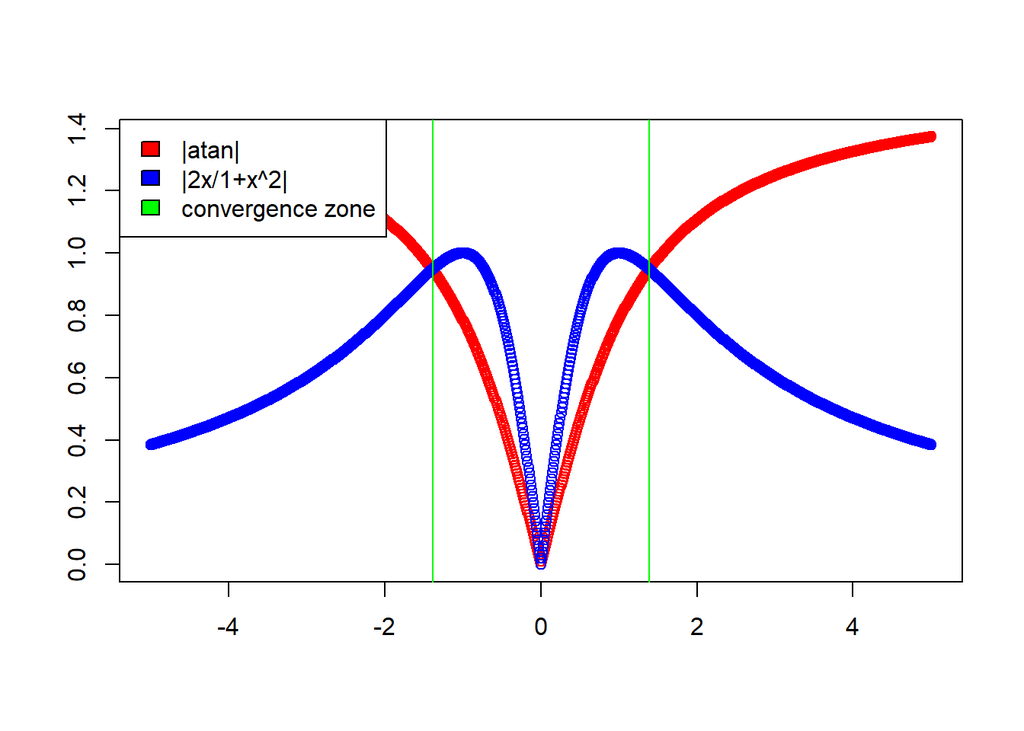

```r
t <- seq(-5,5,0.01)
plot(t, abs(atan(t)), col = "red", xlab = "", ylab = "")
points(t, abs(((2*t)/(1+(t^2)))), col = "blue")
abline(v = c(-1.39,1.39), col = c("green", "green"))
legend("topleft", c("|atan|", "|2x/1+x^2|", "convergence zone"), fill = c("red", "blue", "green"))
```